# rsa-uid-summary

Ben

12/6/2017

```r
library(doParallel)
library(dplyr)
library(ggplot2)
library(tidyr)
setwd("/Users/benpeloquin/Desktop/Projects/rsa_uid/")
```

# Information-theoretic account of **listener expectations** during disfluency

### Speaker / listener models

Standard RSA with noise-aware listeners / speakers.

$P_{L_0} \propto P(m)\sum_{u_i:m\in[[u_i]]}P(u_i)\times P_{Noise}(u_p|u_i)$

$P_{S_1}(u|m) \propto e^{\alpha U(u|m)}$

$U(u|m) \propto \sum_{u_i}P_{Noise}(u_p|u_i)\times log(P_{L_0}(m|u_p))-cost(u_i)$

$P_{L_1}(m|u) \propto \lambda \times \sum_{m\in M}P_{Noise}(u_i|u_p)P_{S_1}(u_i|m)$

```
Noise <- function(theta) {
  return function(utterance) {
      var tokens = utterance.split(' ')
      var index = sample(RandomInteger({n:tokens.length}))
      var replacement = transformFn(index)
      return _removeEmptyItems(replaceIndex(tokens, index, replacement)).join(' ')
    }
}
```

### Um-implicature

```
## run time: 0.4399833
```

Noise-aware listeners who reason about noise-aware speakers generate “um”-implicature – preference for high-surpsial items given UID cue (“um”).

$U \in \{``X a", ``X b", ``a", ``b"\}$

$P(U=u) = [0.1666667, 0.3333333, 0.1666667, 0.3333333]$

$M \in \{\{a\}, \{b\}\}$

$P(M=m) = [0.2, 0.8]$

To get this result I needed to introduce `lambda` a listener-level rationality parameter. Note that listeners are more likely to generate the implicature as a function of noise (`theta`). This result depends on a noise-aware literal listener who reasons about intended utterances from produced utterances $P_{Noise}(u_p|u_i)$.

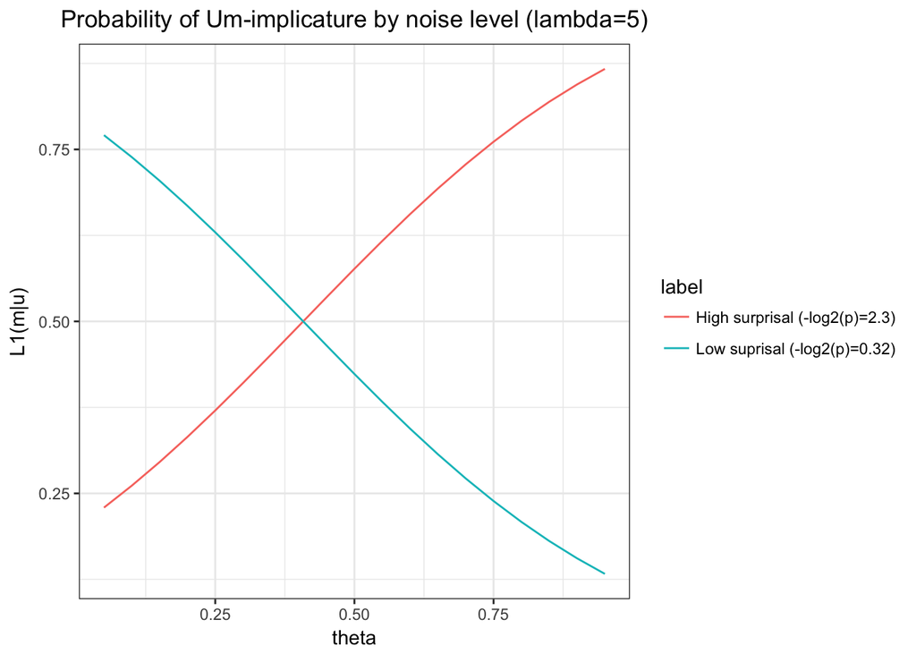

```r
df %>%
  mutate(label=ifelse(d=='a', 'High surprisal (-log2(p)=2.3)', 'Low suprisal (-log2(p)=0.32)')) %>%
  ggplot(aes(x=theta, y=prob, col=label)) +
    geom_line() +
    xlab('theta') +
    ylab('L1(m|u)') +
    ggtitle(paste0('Probability of Um-implicature by noise level', ' (lambda=', LAMBDA, ')')) +
    theme_bw() +
    theme(plot.title = element_text(hjust = 0.5))
```

### Proposed experiment: high(er) surprisal bias given disfluency cue.

Foxtree & Clark (2002) argue that speakers *use* disfluencies such as *um* and *uh* to implicate processing difficulties to listeners. Further, listeners should take advantage of these cues. In one study (Barr, 1998) listeners had to point to abstract shapes on a computer monitor while listening to descriptions. When the shapes were new, listeners responded faster and moved their cursors toward them faster when the descriptions were preceded by um. Under this account speaker disfluencies may effect listener expectations about the surprisal of following content.

In this experiment we test this hypothesis using sentence fragments from the Switchboard corpus. Listeners are presented a incomplete sentence fragment and asked to choose the best candidate to complete the sentence. `Candidates` are chosen from a language model (one high surprisal, one medium surprisal, one low surprisal). Presence of an original disfluency is manipulated - the prediction being that presence of the dislfluency should bias listeners toward high-suprisal content.

Here’s an example design (just in a notebook and without controlling for candidate grammaticality or surprisal).

[figure not shown]

# A pragmatic/info-theoretic account of disfluency **production**.

## Speaker modeling

```
## run time: 1.902883
```

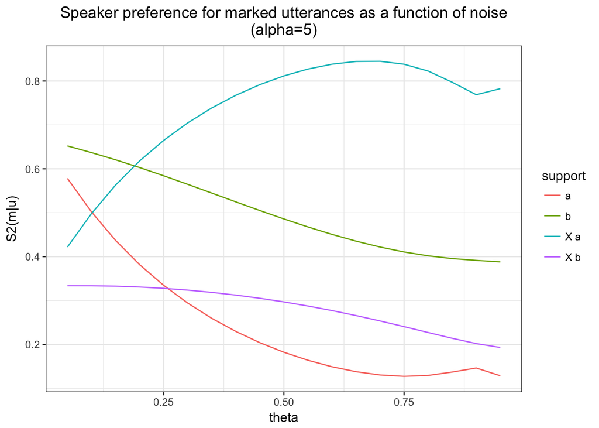

```r
df %>%
  filter((support %in% c('X a', 'a') & speakerInput=='a') | (support %in% c('X b', 'b') & speakerInput=='b')) %>%
  ggplot(aes(x=theta, y=prob, col=support)) +
    geom_line() +
    xlab('theta') +
    ylab(paste0(MODEL, '(m|u)')) +
    ggtitle(paste0('Speaker preference for marked utterances as a function of noise\n', '(alpha=', ALPHA, ')')) +
    theme_bw() +
    theme(plot.title = element_text(hjust = 0.5))
```

### Reproducing Levy & Jaeger (2007) Fig1 with disfluencies in Switchboard.

Do speakers produce disfluencies prior to high-informativity content? Analysis of switchboard data.

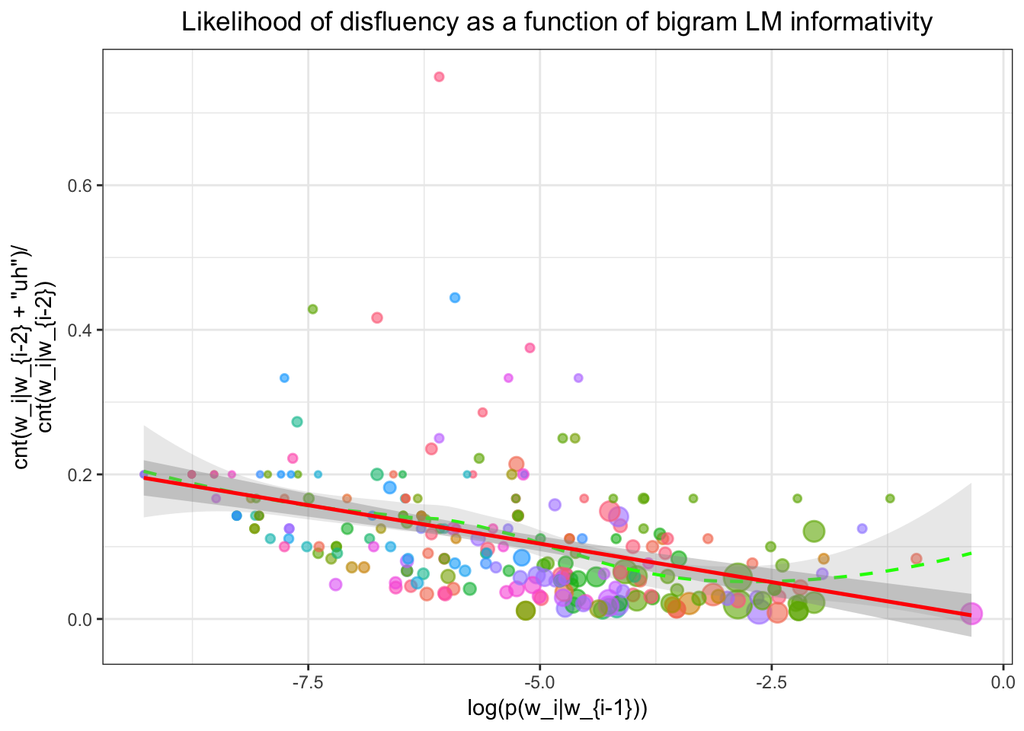

```r
dfSB %>%
  filter(total > 4, before!='^') %>%
  ggplot(aes(x=supr, y=lik, size=total)) +
    geom_point(aes(col=after), alpha=0.6, stroke=0.75) +
    geom_smooth(method='loess', group=0, lty=2, size=0.75, alpha=0.2, col='green') +
    geom_smooth(method='lm', group=0, col='red', size=0.9) +
    xlab('log(p(w_i|w_{i-1}))') +
    ylab('cnt(w_i|w_{i-2} + "uh")/\ncnt(w_i|w_{i-2})') +
    ggtitle('Likelihood of disfluency as a function of bigram LM informativity') +
    theme_bw() +
    theme(plot.title=element_text(hjust = 0.5),
          legend.position="none")
```

This the basic direction of the effect as documented in Levy & Jaeger (2007) Fig1.

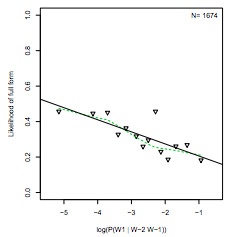

“Levy & Jaeger (2007), Fig1”

### Note

- removed sentence initial disfluencies.
- removed bigrams with $< 5$ instances.

## Modeling switchboard speaker data

### Inferring SB `noise-level`

What is a realistic level of noise in a dialogue corpus like Switchboard? Can we model the data generating process from our speakers and infer `theta`?

`NOTE` this is incomplete work – this is being run on a fraction of the total (relevant) SB data.

```
## run time 39.5705
```

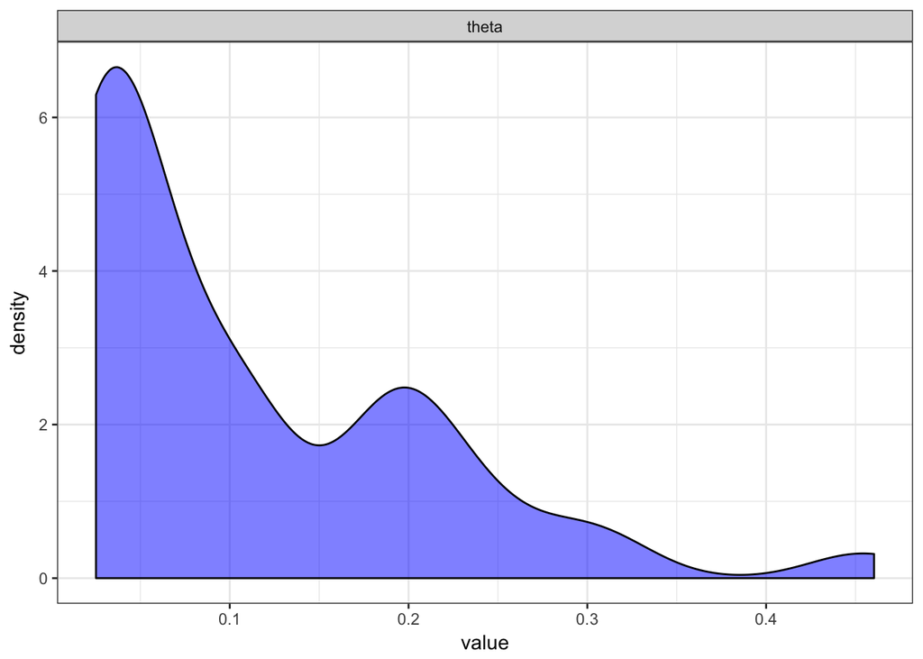

```r
df %>%
  ggplot(aes(x=value)) +
    geom_density(fill='blue', alpha=0.5) +
    facet_grid(~Parameter, scales='free') +
    theme_bw()
```

### Modeling SB data with `S1 speaker`

Can we use RSA as a classifier? That is, can we predict the instances in which a speaker is likely to be disfluent?

`NOTE` this is incomplete work – this is being run on a fraction of the total (relevant) SB data.

```r
# dfSB %>%
#   filter(total > 4, before!='^') %>%
```

```
## run time: 0.8845333
```

`NOTE` this is incomplete work – this is being run on a fraction of the total (relevant) SB data.

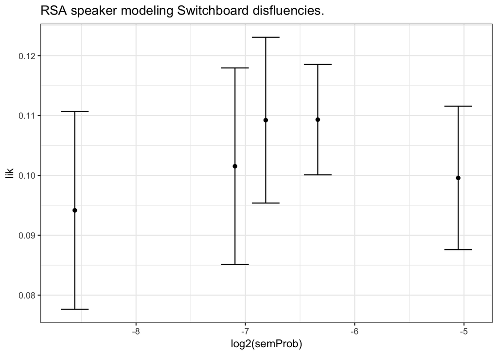

```r
df_bda %>%
  mutate(isMarked=ifelse(res=='X a', 1, 0)) %>%
  group_by(semProb) %>%
  summarise(nMarked=sum(isMarked),
            total=n(),
            lik=nMarked/total,
            ymin=lik+qnorm(0.025)*sqrt(lik*(1-lik)/total),
            ymax=lik+qnorm(0.975)*sqrt(lik*(1-lik)/total)) %>%
  ggplot(aes(x=log2(semProb), y=lik)) +
    geom_errorbar(aes(ymax=ymax, ymin=ymin)) +
    geom_point() +
    theme_bw() +
    ggtitle('RSA speaker modeling Switchboard disfluencies.')
```

# Corpus generation

```r
# Add code from https://htmlpreview.github.io/?https://github.com/benpeloquin7/rsa-uid/blob/master/Analyses/rsa-uid-corpus-generation-20171201.html
```

# Paper scaffolding

## Intro

A remarkable result of the expressivity of natural language is the ability to communicate about a potentially infinite set of meanings from a finite set of tools (citation). But, by this same mechanism speakers may confront a potentially infinite number of ways to communicate just a single meaning. How do we navigate this decision space?

Under one view, the Uniform Information Density hypothesis (UID), if speakers are rational and communication takes place in a noisy environment, they should attempt to optimize communicative properties of their signal. In particular, speakers should plan their utterance so that its information rate is both uniform and close to channel capacity (Levy & Jaeger 2007). One interpretation of this hypothesis frames utterance production as a function of both speaker and listener considerations – speakers should attempt to minimize listener comprehension difficulty while avoiding disproportionately costly utterances (Levy & Jaeger 2007). While UID and UID-related work has successfully characterized aspects of production at multiple levels of abstraction (Aylett & Turk, 2004, Bell et al. 2003, Frank & Jaeger, 2008, Levy & Jaeger, 2007, Genzel & Charniak, 2002) it has done so without an explicit representation of listeners.

In the following work, we address listener representation directly – exploring the degree to which UID effects can emerge in speakers who reason about how listeners will interpret their utterances under noise conditions. To do so, we employ a class of computational pragmatics models known as rational speech act models (RSA) (Goodman & Frank, 2016, Frank & Goodman, 2012) conducting a series of experiments simulating UID-like effects in pragmatic agents. Under this view, UID effects are related to both processing (cost) and pragmatic (social reasoning) mechanisms.

We begin with an overview of UID and RSA, discussing shared and diverging components. Next, we propose a modified RSA model, introducing a noisy channel into the framework (noisy-RSA). Following an analysis of noisy-RSA speaker / listener behavior we conduct a series of experiments aimed at replicating UID effects found in Levy & Jaeger (2007). We end with a discussion of our findings and a summary of next steps.

## Uniform Information Density

## Rational Speech-act theory

## Simulations

### Speaker preference to mark utterances when they are high surprisal

### Listener “um”-implicature

### Replicating Levy & Jaeger (2007)